# HDF5 Python & Matlab Tutorial

Erik Quaeghebeur

2017-02-23

HDF5—Hierarchical Data Format—is a binary data format designed to store and organize large amounts of data. It allows:

- *convenient access* to the stored data from programming languages such as Python and Matlab,
- *annotation and hierarchical structuring* of the data, and
- *efficient storage* of the data.

The fact that the data can be structured and annotated, allows for helpful self-documentation, i.a., one file holds both the data and its description. This goes far beyond, e.g., what is reasonable to put in the headers of a spreadsheet.

Efficient storage makes it possible to store and transfer larger amounts of data than is possible with other formats, such as CSV or Excel. The storage gains are of the order of a factor 10 when comparing to, e.g., uncompressed CSV and a factor 2 when comparing to compressed CSV. The storage efficiency is due to the use of transparent compression and binary data formats (e.g., float and int types) rather than as text.

This tutorial will show how to use Python and Matlab to *read and explore* the data in an HDF5-files. (In case you are interested in *writing* HDF5 files, first work through this tutorial and then consult the documentation of the HDF5 tools used here. I would also be glad to exchange experiences.) We take a file with meteorological from the off-shore met mast at the OWEZ off-shore wind farm as our working example. Feedback to improve the tutorial is welcome.

Some more information:

- [HDF5 website](https://support.hdfgroup.org/HDF5/)
- [HDF5 on Wikipedia](https://en.wikipedia.org/wiki/Hierarchical_Data_Format)
- [OWEZ website](http://www.noordzeewind.nl/)

# Python

## Required Software

Next to Python, we will be using the standard library package [datetime](https://docs.python.org/3.4/library/datetime.html) and the external packages [h5py](http://www.h5py.org/), [numpy](http://www.numpy.org/), and [matplotlib](http://matplotlib.org/). So make sure to install these if they aren't already. We will be using Python 3.4, but any version including 2.7 should work.

This tutorial will be console-based. You can use the standard Python console, [IPython](https://ipython.org/), or some Python IDE, e.g., [Spyder](https://pythonhosted.org/spyder/). I assume that you are familiar with working with a Python console.

## Preparing the Stage

First, we need to import the packages we are going to use:

```python
>>> import numpy as np
>>> import matplotlib.pyplot as plt
>>> import datetime as dt
>>> import h5py
```

Of this set of packages, only h5py is really required to explore HDF5 files, but the others are useful for playing with the data therein.

More information:

- [h5py documentation](http://docs.h5py.org/en/latest/)

## A First Look

Now, let us open the HDF5 file and have a first look at what is inside:

```python
>>> f = h5py.File('OWEZ.h5')

>>> dict(f)
{'channel': <HDF5 group "/channel" (48 members)>,
 'coordinates': <HDF5 group "/coordinates" (3 members)>,
 'device': <HDF5 group "/device" (9 members)>,
 'time': <HDF5 group "/time" (6 members)>}
```

Here, I am assuming that your present working directory (`pwd`) contains the HDF5 file `OWEZ.h5`. We see that the file object `f` provides a `dict`-like interface to its contents. These contents can be groups or datasets, ordered in a hierarchical structure comparable to a file system. In the file system analogy, groups correspond to directories and datasets correspond to files. (There also exist hard and soft links, but that would lead too far for this tutorial)

Every element of the hierarchical structure can be annotated with attribute–value pairs, which are accessed via the `dict`-like `attrs` attribute:

```python
>>> list(f.attrs.keys())
['description',
 'source',
 'author',
 'annotations',
 'data_processing',
 'HDF5-conversion',
 'references']

>>> print(repr(f.attrs['description'][:60] + '…'))
'This file mainly contains the datasets of the met mast at th…'
```

## Digging Deeper

Let us have a look at one of the groups:

```python
>>> for key, value in f['channel'].attrs.items():
...    print(key + ':', repr(value[:60] + '…'))
...
description: 'This group contains the channel-based ordering of the datase…'

>>> dict(f['channel'])
{'00': <HDF5 group "/channel/00" (4 members)>,
 '01': <HDF5 group "/channel/01" (4 members)>,
 '02': <HDF5 group "/channel/02" (4 members)>,
 '03': <HDF5 group "/channel/03" (4 members)>,
 '04': <HDF5 group "/channel/04" (4 members)>,
 '05': <HDF5 group "/channel/05" (4 members)>,
 '06': <HDF5 group "/channel/06" (4 members)>,
 '07': <HDF5 group "/channel/07" (4 members)>,
 '08': <HDF5 group "/channel/08" (4 members)>,
 '09': <HDF5 group "/channel/09" (4 members)>,
 '10': <HDF5 group "/channel/10" (4 members)>,
 '11': <HDF5 group "/channel/11" (4 members)>,
 '12': <HDF5 group "/channel/12" (4 members)>,
 '13': <HDF5 group "/channel/13" (4 members)>,
 '14': <HDF5 group "/channel/14" (4 members)>,
 '15': <HDF5 group "/channel/15" (4 members)>,
 '16': <HDF5 group "/channel/16" (4 members)>,
 '17': <HDF5 group "/channel/17" (4 members)>,
 '18': <HDF5 group "/channel/18" (4 members)>,
 '19': <HDF5 group "/channel/19" (4 members)>,
 '20': <HDF5 group "/channel/20" (4 members)>,
 '21': <HDF5 group "/channel/21" (4 members)>,
 '22': <HDF5 group "/channel/22" (4 members)>,
 '23': <HDF5 group "/channel/23" (4 members)>,
 '24': <HDF5 group "/channel/24" (4 members)>,
 '25': <HDF5 group "/channel/25" (4 members)>,
 '26': <HDF5 group "/channel/26" (4 members)>,
 '27': <HDF5 group "/channel/27" (4 members)>,
 '28': <HDF5 group "/channel/28" (4 members)>,
 '29': <HDF5 group "/channel/29" (4 members)>,
 '30': <HDF5 group "/channel/30" (4 members)>,
 '31': <HDF5 group "/channel/31" (4 members)>,
 '32': <HDF5 group "/channel/32" (4 members)>,
 '33': <HDF5 group "/channel/33" (4 members)>,
 '34': <HDF5 group "/channel/34" (4 members)>,
 '35': <HDF5 group "/channel/35" (4 members)>,
 '36': <HDF5 group "/channel/36" (4 members)>,
 '37': <HDF5 group "/channel/37" (4 members)>,
 '38': <HDF5 group "/channel/38" (4 members)>,
 '50': <HDF5 group "/channel/50" (4 members)>,
 '51': <HDF5 group "/channel/51" (4 members)>,
 '52': <HDF5 group "/channel/52" (4 members)>,
 '53': <HDF5 group "/channel/53" (4 members)>,
 '54': <HDF5 group "/channel/54" (4 members)>,
 '55': <HDF5 group "/channel/55" (4 members)>,
 '56': <HDF5 group "/channel/56" (4 members)>,
 '57': <HDF5 group "/channel/57" (4 members)>,
 '58': <HDF5 group "/channel/58" (4 members)>}
```

```python
>>> f['channel']['00']
<HDF5 group "/channel/00" (4 members)>

>>> f['channel/05']
<HDF5 group "/channel/05" (4 members)>
```

Let us go further down the hierarchy still and see what's inside one of these channels:

```python
>>> c13 = f['channel/13']

>>> dict(c13.attrs)
{'channel': '13', 'device': 'CA', 'location': 'NE70', 'quantity': 'ws'}

>>> dict(c13)
{'Max': <HDF5 dataset "Max": shape (289296,), type "<f2">,
 'Mean': <HDF5 dataset "Mean": shape (289296,), type "<f4">,
 'Min': <HDF5 dataset "Min": shape (289296,), type "<f2">,
 'StdDev': <HDF5 dataset "StdDev": shape (289296,), type "<f2">}
```

The group attributes tersely tell us this channel contains wind speed data from a cup anemometer from the North-East end of the tower at 70 meters height. We see that this group contains some datasets. Each contains 289296 data points in a linear array. All data points in each dataset have the same type. These datasets of channel 13 contain 2 or 4-byte floating point numbers.

## Toying with Datasets

Let us have a look at these datasets (click pictures to unscale/rescale them):

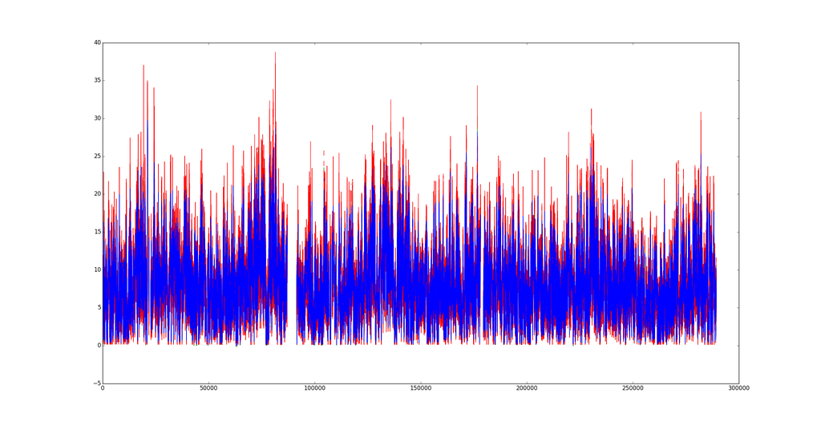

```python
>>> c13['Mean'].value
array([  3.44060493,   3.26941991,   3.32937908, ...,   8.77543259,
         9.77739906,  10.2571497 ], dtype=float32)

>>> c13Min, c13Max, c13Mean, c13StdDev = \
... c13['Min'].value, c13['Max'].value, c13['Mean'].value, c13['StdDev'].value

>>> plt.plot(c13Mean + c13StdDev, 'g'), plt.plot(c13Mean - c13StdDev, 'g'), \
... plt.plot(c13Min, 'r'), plt.plot(c13Max, 'r'), \
... plt.plot(c13Mean, 'b');
```

We see that the values are what is to be expected of wind speed measurements. There are, however, some gaps. These are due to missing data, which is encoded as float ‘NaN’ (Not-a-Number) values. What's the percentage of these in the dataset? Do we need to worry about those when analyzing the data? (Yes!)

```python
>>> np.round(np.mean(np.isnan(c13Mean)) * 100)
8.0 # The 0 after the decimal sign gives the wrong impression
    # that it is rounded to one decimal place; it isn't,
    # it is rounded to the nearest integer

>>> np.mean(c13Mean)
nan

>>> np.nanmean(c13Mean)
8.1629915

>>> np.nanmin(c13Mean), np.nanmax(c13Mean)
(0.0, 29.725368)
```

Furthermore, the plot we showed is not all that legible; let us make a more interesting one by zooming in on the first day of—10-minute—data:

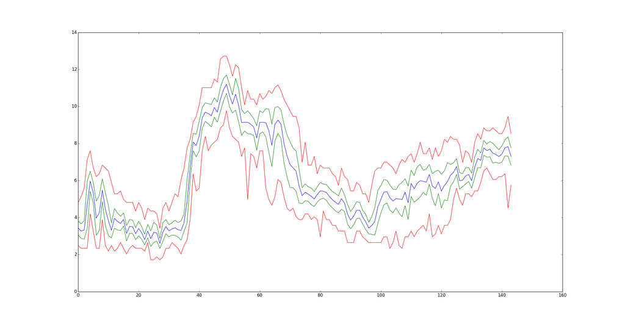

```python
>>> s = slice(6*24)
>>> plt.plot(c13Mean[s] + c13StdDev[s], 'g'), plt.plot(c13Mean[s] - c13StdDev[s], 'g'), \
... plt.plot(c13Min[s], 'r'), plt.plot(c13Max[s], 'r'), \
... plt.plot(c13Mean[s], 'b');
```

Datasets can also have attributes, but that is not being used in the OWEZ HDF5 file we are using here. One use case for that would be to store data that is removed for some reason from the dataset. In our file, this has been done at the group (channel) level. We first look at which channels have which attributes and then have a look at an ‘interesting’ one:

```python
>>> key2channel = dict()
... for channel, group in f['channel'].items():
...    for key in group.attrs.keys():
...        if key not in key2channel:
...            key2channel[key] = {channel}
...        else:
...            key2channel[key].add(channel)
... for key, channels in key2channel.items():
...    print(repr(key) + ':', channels)
...
'replaced_data/timestamp': {'03', '23'}
'location': {'50', '52', '13', '35', '08', '33', '51', '56', '31', '01', '07',
'58', '09', '21', '38', '16', '30', '19', '10', '04', '18', '25', '03', '26',
'55', '00', '54', '05', '14', '53', '36', '15', '27', '28', '34', '57', '11',
'32', '29', '20', '22', '23', '02', '17', '06', '24', '37', '12'}
'quantity': {'50', '52', '13', '35', '08', '33', '51', '56', '31', '01', '07',
'58', '09', '21', '38', '16', '30', '19', '10', '04', '18', '25', '03', '26',
'55', '00', '54', '05', '14', '53', '36', '15', '27', '28', '34', '57', '11',
'32', '29', '20', '22', '23', '02', '17', '06', '24', '37', '12'}
'device': {'50', '52', '13', '35', '08', '33', '51', '56', '31', '01', '07',
'58', '09', '21', '38', '16', '30', '19', '10', '04', '18', '25', '03', '26',
'55', '00', '54', '05', '14', '53', '36', '15', '27', '28', '34', '57', '11',
'32', '29', '20', '22', '23', '02', '17', '06', '24', '37', '12'}
'replaced_data/Max': {'03', '23'}
'replaced_data/Mean': {'03', '23'}
'replaced_data/Min': {'03', '23'}
'replaced_data/description': {'03', '23'}
'channel': {'50', '52', '13', '35', '08', '33', '51', '56', '31', '01', '07',
'58', '09', '21', '38', '16', '30', '19', '10', '04', '18', '25', '03', '26',
'55', '00', '54', '05', '14', '53', '36', '15', '27', '28', '34', '57', '11',
'32', '29', '20', '22', '23', '02', '17', '06', '24', '37', '12'}
'replaced_data/StdDev': {'03', '23'}

>>> for key, value in f['channel/23'].attrs.items():
...    if key.startswith('replaced_data'):
...        print(key.split('/')[1] + ':', repr(value))
...
description: 'Data with negative Min, Max, and Mean values do not make sense
for a relative humidity percentage value, so these were replaced by NaNs'
timestamp: array([1163225400, 1163226000, 1163226600, ..., 1163671800, 1163674200,
       1163719800], dtype=int32)
Max: array([-24.97421225, -24.9781796 , -24.98016327, ..., -24.78973069,
       -24.85717556, -24.87701229])
Min: array([-24.98214695, -24.98016327, -24.98214695, ..., -25.        ,
       -25.        , -24.98214695])
Mean: array([-24.97897307, -24.9799649 , -24.98115511, ..., -24.90676738,
       -24.92025635, -24.97044328])
StdDev: array([ 0.00268   ,  0.000627  ,  0.00105   , ...,  0.07434584,
        0.05914761,  0.03284162])
```

Next to the description, which describes why the values were removed, and the removed values themselves, also—obviously—timestamps of the removed data points are listed, so that we can reconstruct the original datasets, if needed.

## Exploring the Hierarchy

Now that we know what groups and datasets are, we can explore the structure of the HDF5 file a bit more, to learn how it can be used to store the datasets in a self-describing way.

As a reminder, let us recall the highest level of the file:

```python
>>> dict(f)
{'channel': <HDF5 group "/channel" (48 members)>,
 'coordinates': <HDF5 group "/coordinates" (3 members)>,
 'device': <HDF5 group "/device" (9 members)>,
 'time': <HDF5 group "/time" (6 members)>}
```

We have looked at the `'channel'` group, which structured the datasets according to the scheme used in the original Excel data files.

### Time

From the original files however, the time instant columns were ‘moved’:

```python
>>> dict(f['time'])
{'day': <HDF5 dataset "day": shape (289296,), type "|i1">,
 'hour': <HDF5 dataset "hour": shape (289296,), type "|i1">,
 'minute': <HDF5 dataset "minute": shape (289296,), type "|i1">,
 'month': <HDF5 dataset "month": shape (289296,), type "|i1">,
 'timestamp': <HDF5 dataset "timestamp": shape (289296,), type "<i4">,
 'year': <HDF5 dataset "year": shape (289296,), type "<i2">}

>>> f['time/timestamp'].attrs['description']
'The time instances encoded in unix time, the number of seconds that have elapsed since 1970-01-01T00:00:00 (UTC).'
>>> f['time/timestamp'].value
array([1120176000, 1120176600, 1120177200, ..., 1293838200, 1293838800,
       1293839400], dtype=int32)
>>> t = f['time/timestamp'].value

>>> f['time/year'].value
array([2005, 2005, 2005, ..., 2011, 2011, 2011], dtype=int16)
>>> y = f['time/year'].value

>>> f['time/month'].value
array([7, 7, 7, ..., 1, 1, 1], dtype=int8)
>>> m = f['time/month'].value
```

We have saved the timestamp, year and month values for convenient indexing.

### Device–Quantity–Location Hierarchy

The datasets are also available in an alternative structure from the channel one. Namely, they can be accessed through the device–quantity–location hierarchy:

```python
>>> f['device'].attrs['description'][:72] + '…'
'This group contains a device/quantity/location ordering of the datasets.…'
>>> d = f['device']
>>> dict(d)
{'AC': <HDF5 group "/device/AC" (2 members)>,
 'AWAC': <HDF5 group "/device/AWAC" (9 members)>,
 'CA': <HDF5 group "/device/CA" (1 members)>,
 'HMP': <HDF5 group "/device/HMP" (2 members)>,
 'PD': <HDF5 group "/device/PD" (1 members)>,
 'RPT': <HDF5 group "/device/RPT" (1 members)>,
 'ST': <HDF5 group "/device/ST" (1 members)>,
 'WM': <HDF5 group "/device/WM" (3 members)>,
 'WV': <HDF5 group "/device/WV" (1 members)>}

>>> dict(d['HMP'])
{'at': <HDF5 group "/device/HMP/at" (3 members)>,
 'rh': <HDF5 group "/device/HMP/rh" (3 members)>}
>>> set(d['HMP'].attrs.keys())
{'description', 'make', 'note', 'owez_code', 'reference', 'type'}
>>> d['HMP'].attrs['description']
'relative humidity and ambient temperature sensors'

>>> at = d['HMP/at']
>>> set(at.attrs.keys())
Out[36]:
{'accuracy',
 'description',
 'error_propagation',
 'range',
 'sampling_frequency',
 'storage',
 'temperature_dependence',
 'unit'}
>>> at.attrs['description'], at.attrs['unit'], at.attrs['range'], at.attrs['accuracy']
('ambient temperature', '°C', '-40°C..+80°C', '0.1°C (at 20°C)')
>>> dict(at)
{'S116': <HDF5 group "/device/HMP/at/S116" (4 members)>,
 'S21': <HDF5 group "/device/HMP/at/S21" (4 members)>,
 'S70': <HDF5 group "/device/HMP/at/S70" (4 members)>}

>>> dict(at['S70'].attrs)
{'channel': '19', 'device': 'HMP', 'location': 'S70', 'quantity': 'at'}
>>> at.get('S70', getlink=True)
<SoftLink to "/channel/19">
```

So we see that in this alternative hierarchy, the datasets can be reached by specifying the device, quantity, and location, in that order. At that point, we find again the same datasets we encountered in the flat channel hierarchy. These have been grafted here using so-called ‘soft’ links (this does not matter much in practice).

What is especially convenient about such a more descriptive hierarchy is that at the right level metadata of interest can be added. For example references to device make and data sheets:

```python
>>> d['HMP'].attrs['make']
'Vaisala Oyj'
>>> d['HMP'].attrs['reference'][:72] + '…'
"HMP230 Series Transmitters User's Guide (2002-05) from Vaisala Oyj <http…"
```

Given that it is natural that each quantity is treated in the same way, information about the data processing is stored at that level:

```python
>>> at.attrs['sampling_frequency']
'unknown (assumed to be smaller than 3495 Hz)'
>>> at.attrs['error_propagation']
'Given that √(3495*600) is about 1500, a lower bound of the accuracy of Mean values is 0.1°C/1500 = ⅔·10¯⁴°C.'
>>> at.attrs['storage'][:72] + '…'
'The Max and Min values are stored as float16 values, which results in a …'
```

(As you see, attributes can store anything, even information that shows an embarrassing lack of knowledge!)

## Toying with Datasets Again

Plotting against the timestamps is straightforward:

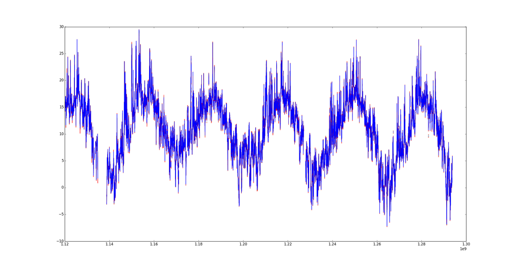

```python
>>> at70Min, at70Max, at70Mean, at70StdDev = \
... at70['Min'].value, at70['Max'].value, at70['Mean'].value, at70['StdDev'].value

>>> plt.plot(t, at70Mean + at70StdDev, 'g'), plt.plot(t, at70Mean - at70StdDev, 'g'), \
... plt.plot(t, at70Min, 'r'), plt.plot(t, at70Max, 'r'), \
... plt.plot(t, at70Mean, 'b');
```

The seasonal variation in temperature is clearly apparent and should be expected.

Zooming in on a specific part—e.g., the summer of 2009—of the dataset is simplified by using the year and month indexes we encountered earlier:

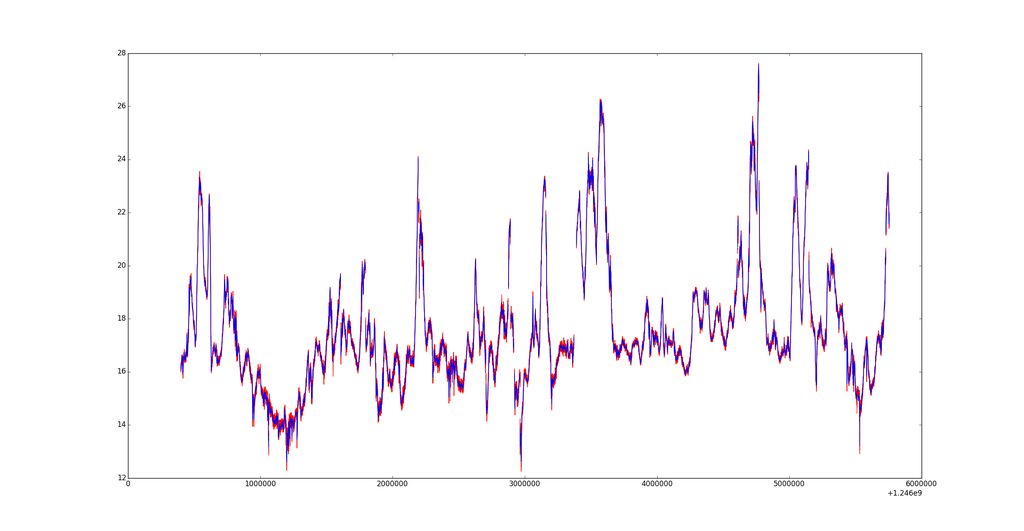

```python
>>> s = (y == 2009) & (m > 6) & (m < 9)
>>> plt.plot(t[s], at70Mean[s] + at70StdDev[s], 'g'), plt.plot(t[s], at70Mean[s] - at70StdDev[s], 'g'), \
... plt.plot(t[s], at70Min[s], 'r'), plt.plot(t[s], at70Max[s], 'r'), \
... plt.plot(t[s], at70Mean[s], 'b');
```

Now the diurnal variation starts to become apparent.

The highest temperature seems to have occurred in the second half of August, but let's find this out more precisely.

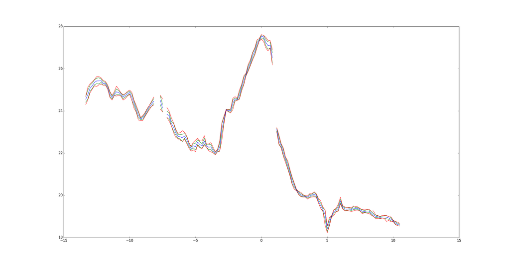

```python
>>> np.nanmax(at70Max[s])
27.609

>>> i = np.argmax(at70Max[s])
>>> at70Max[s][i]
nan

>>> b = ~np.isnan(at70Max[s])
>>> i = np.argmax(at70Max[s][b])
>>> at70Max[s][b][i]
27.609

>>> t[s][b][i]
1250767200
>>> dt.datetime.fromtimestamp(t[s][b][i]).isoformat()
'2009-08-20T13:20:00'

>>> a = f['time/day'].value
>>> s = (y == 2009) & (m == 8) & (a == 20)
>>> b = ~np.isnan(at70Max[s])
>>> i = np.argmax(at70Max[s][b])
>>> h = (t[s] - t[s][b][i])/60/60 # we center the plot at the hottest time
>>> plt.plot(h, at70Mean[s] + at70StdDev[s], 'g'), plt.plot(h, at70Mean[s] - at70StdDev[s], 'g'), \
... plt.plot(h, at70Min[s], 'r'), plt.plot(h, at70Max[s], 'r'), \
... plt.plot(h, at70Mean[s], 'b');
```

## Closing

If you managed to work through all of the above examples, you should be ready to independently work with HDF5 files yourself using the h5py package. Remember that the hierarchy of each HDF5 file can be different, so it will be necessary to acquaint yourself with it a bit before working with the data.

In case you are dealing with a HDF5 file that you want to augment or improve, or if you want to create an HDF5 file for some dataset, I advise you to go over the documentation for the h5py package. Typically, you will also need to use a package to import the data from a CSV or Excel file and create an initial HDF5 file you can start from. I have made good use of the Pandas library for that purpose. It has convenient [input-output routines](http://pandas.pydata.org/pandas-docs/stable/io.html) you can use. When you start modifying HDF5 files, then [`h5repack`](https://support.hdfgroup.org/HDF5/doc/RM/Tools.html#Tools-Repack) is also a necessary tool to clean up old cruft. Also, don't hesitate to contact me with questions; if I have time, I'll gladly help you along.

Success & have fun!

# Matlab

For this Matlab-part of the tutorial, I will be using Matlab 2016b, but non-ancient older versions should work as well.

The latest version of Matlab's own `.mat` file format (7.3) is actually based on HDF5. However, for those files Matlab uses their own pre-defined structure, so this does not have any impact for us, expect perhaps for the fact that Matlab has extensive HDF5 capabilities built-in.

This tutorial will be console-based. Matlab help and documentation for its HDF5 functionality can be accessed by:

```matlab
>> doc hdf5 % Summary of MATLAB hdf5 capabilities.
>> doc h5info % Return information about HDF5 file
>> doc h5disp % Display contents of HDF5 file
>> doc h5read % Read data from HDF5 data set
>> doc h5readatt % Read attribute from HDF5 file
```

Some more information:

- [Matlab example on HDF5 website](https://support.hdfgroup.org/HDF5/examples/api18-m.html)

I would be very grateful for improvement feedback on this Matlab-part of the tutorial, especially on how to more compactly output `struct` (sub)fields.

## A First Look

Now, let us have a first look at what is inside the HDF5 file:

```matlab
>> info = h5info('OWEZ.h5')

ans =

  struct with fields:

      Filename: '/home/equaeghe/temp/OWEZ_M_181/OWEZ.27.h5'
          Name: '/'
        Groups: [4×1 struct]
      Datasets: []
     Datatypes: []
         Links: []
    Attributes: [7×1 struct]

>> {info.Groups.Name}

ans =

  1×4 cell array

    '/channel'    '/coordinates'    '/device'    '/time'
```

Here, I am assuming that your present working directory (pwd) contains the HDF5 file OWEZ.h5. We see that `h5info` provides a `struct` containing a description of the contents of the HDF5 file. These contents can be groups or datasets, ordered in a hierarchical structure comparable to a file system. In the file system analogy, groups correspond to directories and datasets correspond to files. (There also exist hard and soft links, but that would lead too far for this tutorial)

Every element of the hierarchical structure can be annotated with attribute–value pairs, which are discovered and accessed as follows:

```matlab
>> {info.Attributes.Name}

ans =

  1×7 cell array

  Columns 1 through 4

    'description'    'source'    'author'    'annotations'

  Columns 5 through 7

    'data_processing'    'HDF5-conversion'    'references'

>> h5readatt('OWEZ.h5', '/', 'description')

ans =

  cell

    'This file mainly contains the datasets of the met mast at the Egmond aan Zee Offshore Wind Farm…'
```

## Digging Deeper

Let us have a look at one of the groups:

```matlab
>> info_channel = h5info('OWEZ.h5', '/channel')

info_channel =

  struct with fields:

      Filename: '/home/equaeghe/temp/OWEZ_M_181/OWEZ.27.h5'
          Name: '/channel'
        Groups: [48×1 struct]
      Datasets: []
     Datatypes: []
         Links: []
    Attributes: [1×1 struct]

>> {info_channel.Attributes.Name}

ans =

  cell

    'description'

>> info_channel.Attributes.Value

ans =

  cell

    'This group contains the channel-based ordering of the datasets as described in the data manual …'

>> {info_channel.Groups.Name}

ans =

  1×48 cell array

  Columns 1 through 6

    '/channel/00'    '/channel/01'    '/channel/02'    '/channel/03'    '/channel/04'    '/channel/05'

  Columns 7 through 12

    '/channel/06'    '/channel/07'    '/channel/08'    '/channel/09'    '/channel/10'    '/channel/11'

  Columns 13 through 18

    '/channel/12'    '/channel/13'    '/channel/14'    '/channel/15'    '/channel/16'    '/channel/17'

  Columns 19 through 24

    '/channel/18'    '/channel/19'    '/channel/20'    '/channel/21'    '/channel/22'    '/channel/23'

  Columns 25 through 30

    '/channel/24'    '/channel/25'    '/channel/26'    '/channel/27'    '/channel/28'    '/channel/29'

  Columns 31 through 36

    '/channel/30'    '/channel/31'    '/channel/32'    '/channel/33'    '/channel/34'    '/channel/35'

  Columns 37 through 42

    '/channel/36'    '/channel/37'    '/channel/38'    '/channel/50'    '/channel/51'    '/channel/52'

  Columns 43 through 48

    '/channel/53'    '/channel/54'    '/channel/55'    '/channel/56'    '/channel/57'    '/channel/58'
```

Let us go further down the hierarchy still and see what's inside one of these channels:

```matlab
>> info_c24 = h5info('OWEZ.h5', '/channel/24')

info_c24 =

  struct with fields:

      Filename: '/home/equaeghe/temp/OWEZ_M_181/OWEZ.27.h5'
          Name: '/channel/24'
        Groups: []
      Datasets: [4×1 struct]
     Datatypes: []
         Links: []
    Attributes: [4×1 struct]

>> h5disp('OWEZ.h5','/channel/24')
HDF5 OWEZ.27.h5
Group '/channel/24'
    Attributes:
        'channel':  '24'
        'device':  'RPT'
        'quantity':  'ap'
        'location':  'T20'
    Dataset 'Max'
        Size:  289296
        MaxSize:  289296
        Datatype:   H5T_IEEE_F32LE (single)
        ChunkSize:  4521
        Filters:  shuffle, deflate(9)
        Attributes:
            'DIMENSION_LABELS':  'time'
            'DIMENSION_LIST':  H5T_VLEN
    Dataset 'Mean'
        Size:  289296
        MaxSize:  289296
        Datatype:   H5T_IEEE_F32LE (single)
        ChunkSize:  4521
        Filters:  shuffle, deflate(9)
        Attributes:
            'DIMENSION_LABELS':  'time'
            'DIMENSION_LIST':  H5T_VLEN
    Dataset 'Min'
        Size:  289296
        MaxSize:  289296
        Datatype:   H5T_IEEE_F32LE (single)
        ChunkSize:  4521
        Filters:  shuffle, deflate(9)
        Attributes:
            'DIMENSION_LABELS':  'time'
            'DIMENSION_LIST':  H5T_VLEN
    Dataset 'StdDev'
        Size:  289296
        MaxSize:  289296
        Datatype:   16-bit floating point type
        ChunkSize:  9041
        Filters:  shuffle, deflate(9)
        Attributes:
            'DIMENSION_LABELS':  'time'
            'DIMENSION_LIST':  H5T_VLEN
```

The group attributes tersely tell us this channel contains atmospheric pressure data from a resonant pressure transducer from a tower location at 20 meters height. We see that this group contains some datasets. Each contains 289296 data points. All data points in each dataset have the same type. These datasets of channel 24 contain 2 or 4-byte floating point numbers. Further information displayed by `h5disp` falls outside of the scope of this tutorial.

We have not used the `h5disp` function before, because it outputs too much information. Although when passing `'min'` as a third argument, the verbosity is greatly reduced—see the section ‘Appendix: Full Hierarchy Tree’ at the end of this tutorial.

## Toying with Datasets

Let us have a look at these datasets (click pictures to unscale/rescale them):

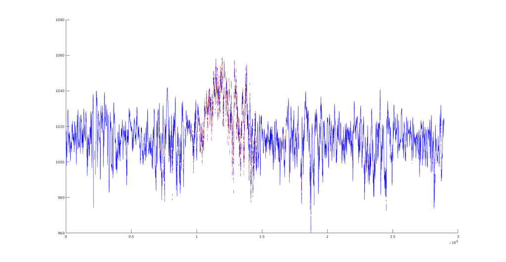

```matlab
>> c24Mean = h5read('OWEZ.h5', '/channel/24/Mean');
>> [n, c] = hist(c24Mean); [n; c]' % used `format longG`

ans =

  10×2 single matrix

              53        965.1703
             749        975.2003
            5594        985.2302
           22034        995.2601
           63612         1005.29
          100846         1015.32
           54119         1025.35
           13105         1035.38
            3412         1045.41
             710         1055.44

>> c24Min = h5read('OWEZ.h5', '/channel/24/Min');
>> c24Max = h5read('OWEZ.h5', '/channel/24/Max');
>> c24StdDev = h5read('OWEZ.h5', '/channel/24/StdDev');

>> h = figure(); hold on;
>> plot(c24Mean + c24StdDev, 'g'), plot(c24Mean - c24StdDev, 'g'),...
plot(c24Min, 'r'), plot(c24Max, 'r'), plot(c24Mean, 'b');
```

We see that the values are what is to be expected of atmospheric pressure measurements. There are, however, some gaps. These are due to missing data, which is encoded as float ‘NaN’ (Not-a-Number) values. What's the percentage of these in the dataset? Do we need to worry about those when analyzing the data? (Yes!)

```matlab
>> round(mean(isnan(c24Mean)) * 100)

ans =

     9

>> mean(c24Mean)

ans =

  single

   NaN

>> nanmean(c24Mean)

ans =

  single

        1014.017

>> [nanmin(c24Min), nanmax(c24Max)]

ans =

  1×2 single row vector

        960.0231        1060.676
```

Furthermore, the plot we showed is not all that legible; let us make a more interesting one by zooming in on the first day of—10-minute—data:

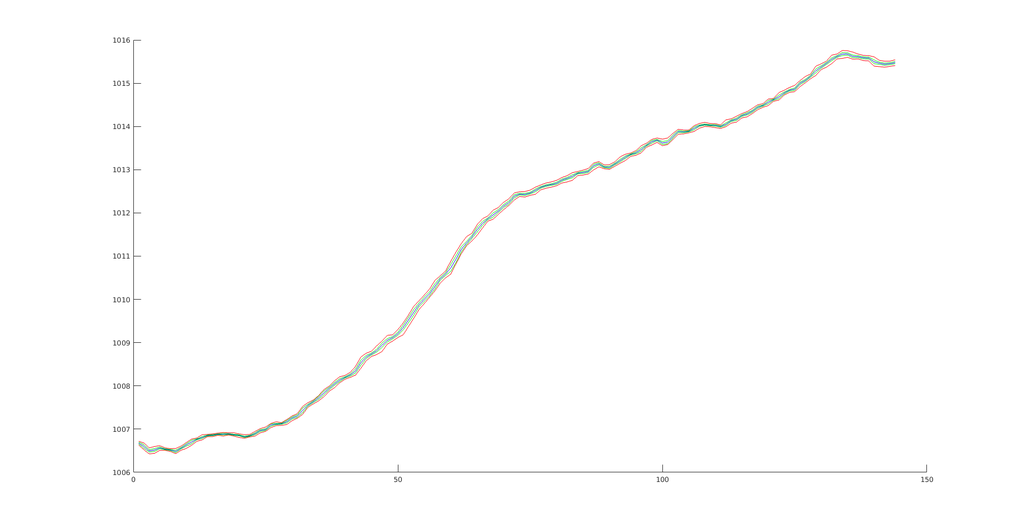

```matlab
>>> s = 1:6*24
>> h = figure(); hold on;
>> plot(c24Mean(s) + c24StdDev(s), 'g'), plot(c24Mean(s) - c24StdDev(s), 'g'),...
plot(c24Min(s), 'r'), plot(c24Max(s), 'r'), plot(c24Mean(s), 'b');
```

Datasets can also have attributes, but that is not being used in the OWEZ HDF5 file we are using here. One use case for that would be to store data that is removed for some reason from the dataset. In our file, this has been done at the group (channel) level. We first look at which channels have which attributes and then have a look at an ‘interesting’ one:

```matlab
>> ciGA = {channel_info.Groups.Attributes};
>> c = containers.Map;

>> for i = 1:length(ciGA),
     ks = {ciGA{i}.Name};
     for j = 1:length(ks),
       if isKey(c, ks{j}),
         c(ks{j}) = [c(ks{j}), i];
       else,
         c(ks{j}) = [i];
       end,
     end,
   end

>> c
c =

  Map with properties:

        Count: 10
      KeyType: char
    ValueType: any

>> keys(c)
ans =

  1×10 cell array

  Columns 1 through 4

    'channel'    'device'    'location'    'quantity'

  Columns 5 through 6

    'replaced_data/Max'    'replaced_data/Mean'

  Columns 7 through 8

    'replaced_data/Min'    'replaced_data/Std…'

  Columns 9 through 10

    'replaced_data/des…'    'replaced_data/tim…'

>> c('replaced_data/description')

ans =

     4    24

>> format compact

>> ciGA4 = ciGA{4}
>> for i = 1:length(ciGA4), disp({ciGA4(i).Name, ciGA4(i).Value}), end
    'replaced_data/description'    {1×1 cell}
    'replaced_data/timestamp'    [43×1 int32]
    'replaced_data/Max'    [43×1 double]
    'replaced_data/Min'    [43×1 double]
    'replaced_data/Mean'    [43×1 double]
    'replaced_data/StdDev'    [43×1 double]
    'channel'    {1×1 cell}
    'device'    {1×1 cell}
    'quantity'    {1×1 cell}
    'location'    {1×1 cell}

>> format loose

>> disp({ciGA4(7).Name, ciGA4(7).Value{1}}) % channels are 0-based
    'channel'    '03'

>> disp(h5readatt('OWEZ.h5', '/channel/03', 'replaced_data/description'))
    'Data with non-integer Min and Max values and very high StdDev values wa…'

>> t = h5readatt('OWEZ.h5', '/channel/03', 'replaced_data/timestamp');
>> t(1:15)

ans =

  15×1 int32 column vector

   1173108600
   1173110400
   1173113400
   1173114000
   1173122400
   1173124800
   1173126000
   1173127200
   1173132600
   1173133800
   1173135000
   1173135600
   1173139200
   1173139800
   1173140400

>> >> s = h5readatt('OWEZ.h5', '/channel/03', 'replaced_data/StdDev');
>> s(1:15)

ans =

  138.6064
  131.0968
  140.1962
  142.3113
  117.8641
  135.3204
  109.8331
  117.0986
  126.1011
  127.5871
  118.0204
  119.9955
  120.0094
  135.0662
  128.4392
```

Next to the description, which describes why the values were removed, and the removed values themselves, also—obviously—timestamps of the removed data points are listed, so that we can reconstruct the original datasets, if needed.

## Exploring the Hierarchy

Now that we know what groups and datasets are, we can explore the structure of the HDF5 file a bit more, to learn how it can be used to store the datasets in a self-describing way.

As a reminder, let us recall the highest level of the file:

```matlab
>> {info.Groups.Name}

ans =

  1×4 cell array

    '/channel'    '/coordinates'    '/device'    '/time'
```

We have looked at the `'channel'` group, which structured the datasets according to the scheme used in the original Excel data files.

### Time

From the original files however, the time instant columns were ‘moved’:

```matlab
>> time_info = h5info('OWEZ.h5', '/time')

time_info =

  struct with fields:

      Filename: '/home/equaeghe/temp/OWEZ_M_181/OWEZ.27.h5'
          Name: '/time'
        Groups: []
      Datasets: [6×1 struct]
     Datatypes: []
         Links: []
    Attributes: [1×1 struct]

>> {time_info.Datasets.Name}

ans =

  1×6 cell array

    'day'    'hour'    'minute'    'month'    'timestamp'    'year'

>> h5readatt('OWEZ.h5', '/time/timestamp', 'description')

ans =

  cell

    'The time instances encoded in unix time, the number of seconds that hav…'

>> t = h5read('OWEZ.h5', '/time/timestamp');
>> t(1:15)

ans =

  15×1 int32 column vector

   1120176000
   1120176600
   1120177200
   1120177800
   1120178400
   1120179000
   1120179600
   1120180200
   1120180800
   1120181400
   1120182000
   1120182600
   1120183200
   1120183800
   1120184400

>> y = h5read('OWEZ.h5', '/time/year');
>> y(1:8), y(end-7:end)

ans =

  8×1 int16 column vector

   2005
   2005
   2005
   2005
   2005
   2005
   2005
   2005


ans =

  8×1 int16 column vector

   2010
   2010
   2011
   2011
   2011
   2011
   2011
   2011

>> m = h5read('OWEZ.h5', '/time/month');
>> m(1:8), m(end-7:end)

ans =

  8×1 int8 column vector

   7
   7
   7
   7
   7
   7
   7
   7


ans =

  8×1 int8 column vector

   12
   12
    1
    1
    1
    1
    1
    1
```

We have saved the timestamp, year and month values for convenient indexing.

### Device–Quantity–Location Hierarchy

The datasets are also available in an alternative structure from the channel one. Namely, they can be accessed through the device–quantity–location hierarchy:

```matlab
>> disp(h5readatt('OWEZ.h5', '/device', 'description'))
    'This group contains a device/quantity/location ordering of the datasets…'

>> info_device = h5info('OWEZ.h5', '/device')

info_device =

  struct with fields:

      Filename: '/home/equaeghe/temp/OWEZ_M_181/OWEZ.27.h5'
          Name: '/device'
        Groups: [9×1 struct]
      Datasets: []
     Datatypes: []
         Links: []
    Attributes: [1×1 struct]

>> disp({info_device.Groups.Name})
  Columns 1 through 4

    '/device/AC'    '/device/AWAC'    '/device/CA'    '/device/HMP'

  Columns 5 through 8

    '/device/PD'    '/device/RPT'    '/device/ST'    '/device/WM'

  Column 9

    '/device/WV'

>> info_WM = h5info('OWEZ.h5', '/device/WM')

info_WM =

  struct with fields:

      Filename: '/home/equaeghe/temp/OWEZ_M_181/OWEZ.27.h5'
          Name: '/device/WM'
        Groups: [3×1 struct]
      Datasets: []
     Datatypes: []
         Links: []
    Attributes: [4×1 struct]

>> disp(h5readatt('OWEZ.h5', '/device/WM', 'description'))
    '3-axis ultrasonic anemometer'

>> disp({info_WM.Groups.Name})
    '/device/WM/hws'    '/device/WM/vws'    '/device/WM/wd'

>> info_vws = h5info('OWEZ.h5', '/device/WM/vws')

info_vws =

  struct with fields:

      Filename: '/home/equaeghe/temp/OWEZ_M_181/OWEZ.27.h5'
          Name: '/device/WM/vws'
        Groups: []
      Datasets: []
     Datatypes: []
         Links: [3×1 struct]
    Attributes: [10×1 struct]

>> disp({info_vws.Attributes.Name})
  Columns 1 through 5

    'description'    'unit'    'range'    'resolution'    'offset'

  Columns 6 through 8

    'accuracy'    'sampling_frequency'    'standard_error'

  Columns 9 through 10

    'error_propagation'    'storage'

>> disp(h5readatt('OWEZ.h5', '/device/WM/vws', 'description')),...
   disp(h5readatt('OWEZ.h5', '/device/WM/vws', 'unit')),...
   disp(h5readatt('OWEZ.h5', '/device/WM/vws', 'range')),...
   disp(h5readatt('OWEZ.h5', '/device/WM/vws', 'accuracy'))
    'vertical wind speed'

    'm/s'

    '0 m/s..60 m/s'

    '1.5%RMS (<20 m/s)'

>> disp({info_vws.Links.Name})
    'NW116'    'NW21'    'NW70'
```

So we see that in this alternative hierarchy, the datasets can be reached by specifying the device, quantity, and location, in that order. At that point, we find again the same datasets we encountered in the flat channel hierarchy. These have been grafted here using so-called ‘soft’ links (this does not matter much in practice).

What is especially convenient about such a more descriptive hierarchy is that at the right level metadata of interest can be added. For example references to device make and type:

```matlab
>> disp({info_WM.Attributes.Name})
    'owez_code'    'make'    'type'    'description'

>> disp(h5readatt('OWEZ.h5', '/device/WM', 'make')),...
   disp(h5readatt('OWEZ.h5', '/device/WM', 'type'))
    'Gill'

    'Windmaster 1086M'
```

Given that it is natural that each quantity is treated in the same way, information about the data processing is stored at that level:

```matlab
>> disp(h5readatt('OWEZ.h5', '/device/WM/vws', 'sampling_frequency')),...
   disp(h5readatt('OWEZ.h5', '/device/WM/vws', 'standard_error')),...
   disp(h5readatt('OWEZ.h5', '/device/WM/vws', 'storage'))
    '4 Hz (2400 samples per 10 min)'

    'Given that √2400 is about 50, the standard error of the Mean, i.e., due…'

    'The Max and Min fields have been stored as float16 values. This results…'
```

## Toying with Datasets Again

Plotting against the timestamps is straightforward:

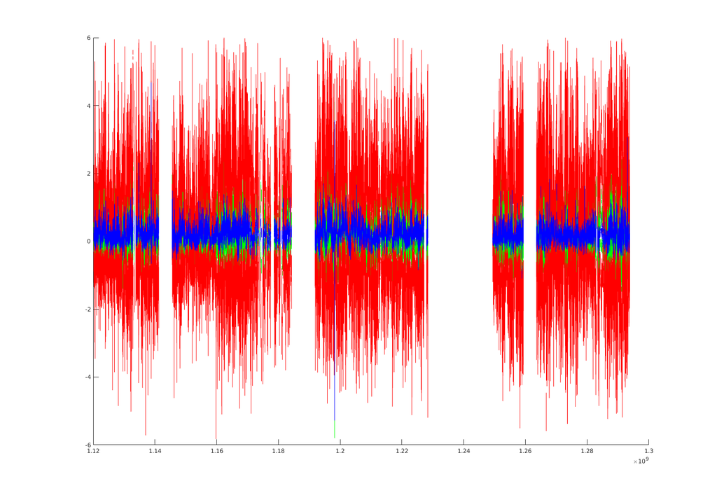

```matlab
>> vws116Mean = h5read('OWEZ.h5', '/device/WM/vws/NW116/Mean');
>> vws116Min = h5read('OWEZ.h5', '/device/WM/vws/NW116/Min');
>> vws116Max = h5read('OWEZ.h5', '/device/WM/vws/NW116/Max');
>> vws116StdDev = h5read('OWEZ.h5', '/device/WM/vws/NW116/StdDev');

>> h = figure(); hold on;
>> plot(t, vws116Mean + vws116StdDev, 'g'), plot(t, vws116Mean - vws116StdDev, 'g'),...
plot(t, vws116Min, 'r'), plot(t, vws116Max, 'r'), plot(t, vws116Mean, 'b');
```

The mean vertical wind speed is usually small, a slight updraft, but with substantially larger extrema over the ten-minute averaging windows.

Zooming in on a specific part—e.g., the winter of 2007–2008—of the dataset is simplified by using the year and month indexes we encountered earlier:

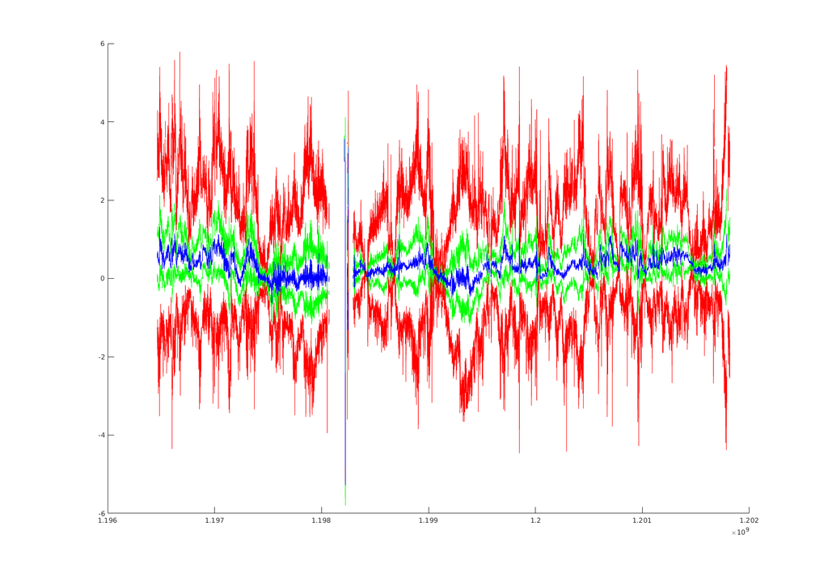

```matlab
>> s = ((y == 2007) & (m == 12)) | ((y == 2008) & (m == 1));
>> h = figure(); hold on;
>> plot(t(s), vws116Mean(s) + vws116StdDev(s), 'g'),...
   plot(t(s), vws116Mean(s) - vws116StdDev(s), 'g'),...
   plot(t(s), vws116Min(s), 'r'), plot(t(s), vws116Max(s), 'r'),...
   plot(t(s), vws116Mean(s), 'b');
```

There seems to be some extreme negative (downward) value in the third week of december; let's find out how extreme and where precisely.

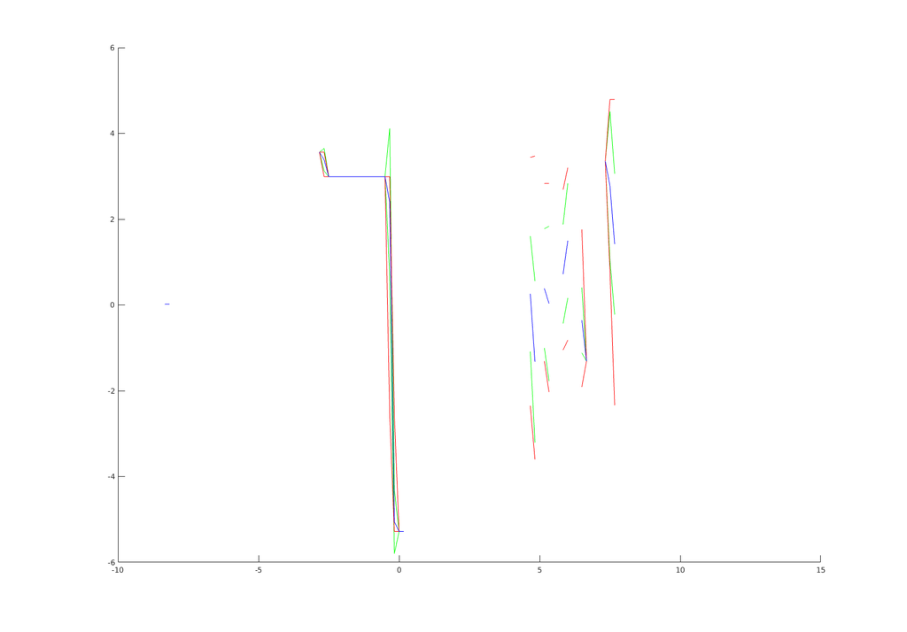

```matlab
>> [vws116Mean_min, i] = nanmin(vws116Mean(s))

vws116Mean_min =

  single

   -5.2800


i =

        2934

>> ts = t(s); ts(i)

ans =

  int32

   1198223400

>> datestr(datetime(ts(i), 'ConvertFrom', 'posixtime'))

ans =

21-Dec-2007 07:50:00

>> a = h5read('OWEZ.h5', '/time/day');
>> s = (y == 2007) & (m == 12) & (a == 21);
>> [vws116Mean_min, i] = nanmin(vws116Mean(s));
>> ts = t(s); tsc = double(ts - ts(i))/60/60; % we center the plot at the extreme value
>> h = figure(); hold on;
>> plot(tsc, vws116Mean(s) + vws116StdDev(s), 'g'),...
   plot(tsc, vws116Mean(s) - vws116StdDev(s), 'g'),...
   plot(tsc, vws116Min(s), 'r'), plot(tsc, vws116Max(s), 'r'),...
   plot(tsc, vws116Mean(s), 'b');
```

Well, that doesn't seem like a good measurement day. Perhaps those data should be cut out because doubts about their reliability.

## Closing

If you managed to work through all of the above examples, you should be ready to independently work with HDF5 files yourself using Matlab. Remember that the hierarchy of each HDF5 file can be different, so it will be necessary to acquaint yourself with it a bit before working with the data.

In case you are dealing with a HDF5 file that you want to augment or improve, or if you want to create an HDF5 file for some dataset, I advise you to go over the Matlab documentation. I haven't used Matlab in the creation and modification of HDF5 files yet, mostly because I have a personal preference for Python. However, don't hesitate to contact me to share experiences.

Success & have fun!

## Appendix: Full Hierarchy Tree

```matlab
>> h5disp('OWEZ.h5', '/', 'min')
HDF5 OWEZ.27.h5
Group '/'
    Group '/channel'
        Group '/channel/00'
            Dataset 'Max'
            Dataset 'Mean'
            Dataset 'Min'
            Dataset 'StdDev'
        Group '/channel/01'
            Dataset 'Max'
            Dataset 'Mean'
            Dataset 'Min'
            Dataset 'StdDev'
        Group '/channel/02'
            Dataset 'Max'
            Dataset 'Mean'
            Dataset 'Min'
            Dataset 'StdDev'
        Group '/channel/03'
            Dataset 'Max'
            Dataset 'Mean'
            Dataset 'Min'
            Dataset 'StdDev'
        Group '/channel/04'
            Dataset 'Max'
            Dataset 'Mean'
            Dataset 'Min'
            Dataset 'StdDev'
        Group '/channel/05'
            Dataset 'Max'
            Dataset 'Mean'
            Dataset 'Min'
            Dataset 'StdDev'
        Group '/channel/06'
            Dataset 'Max'
            Dataset 'Mean'
            Dataset 'Min'
            Dataset 'StdDev'
        Group '/channel/07'
            Dataset 'Max'
            Dataset 'Mean'
            Dataset 'Min'
            Dataset 'StdDev'
        Group '/channel/08'
            Dataset 'Max'
            Dataset 'Mean'
            Dataset 'Min'
            Dataset 'StdDev'
        Group '/channel/09'
            Dataset 'Max'
            Dataset 'Mean'
            Dataset 'Min'
            Dataset 'StdDev'
        Group '/channel/10'
            Dataset 'Max'
            Dataset 'Mean'
            Dataset 'Min'
            Dataset 'StdDev'
        Group '/channel/11'
            Dataset 'Max'
            Dataset 'Mean'
            Dataset 'Min'
            Dataset 'StdDev'
        Group '/channel/12'
            Dataset 'Max'
            Dataset 'Mean'
            Dataset 'Min'
            Dataset 'StdDev'
        Group '/channel/13'
            Dataset 'Max'
            Dataset 'Mean'
            Dataset 'Min'
            Dataset 'StdDev'
        Group '/channel/14'
            Dataset 'Max'
            Dataset 'Mean'
            Dataset 'Min'
            Dataset 'StdDev'
        Group '/channel/15'
            Dataset 'Max'
            Dataset 'Mean'
            Dataset 'Min'
            Dataset 'StdDev'
        Group '/channel/16'
            Dataset 'Max'
            Dataset 'Mean'
            Dataset 'Min'
            Dataset 'StdDev'
        Group '/channel/17'
            Dataset 'Max'
            Dataset 'Mean'
            Dataset 'Min'
            Dataset 'StdDev'
        Group '/channel/18'
            Dataset 'Max'
            Dataset 'Mean'
            Dataset 'Min'
            Dataset 'StdDev'
        Group '/channel/19'
            Dataset 'Max'
            Dataset 'Mean'
            Dataset 'Min'
            Dataset 'StdDev'
        Group '/channel/20'
            Dataset 'Max'
            Dataset 'Mean'
            Dataset 'Min'
            Dataset 'StdDev'
        Group '/channel/21'
            Dataset 'Max'
            Dataset 'Mean'
            Dataset 'Min'
            Dataset 'StdDev'
        Group '/channel/22'
            Dataset 'Max'
            Dataset 'Mean'
            Dataset 'Min'
            Dataset 'StdDev'
        Group '/channel/23'
            Dataset 'Max'
            Dataset 'Mean'
            Dataset 'Min'
            Dataset 'StdDev'
        Group '/channel/24'
            Dataset 'Max'
            Dataset 'Mean'
            Dataset 'Min'
            Dataset 'StdDev'
        Group '/channel/25'
            Dataset 'Max'
            Dataset 'Mean'
            Dataset 'Min'
            Dataset 'StdDev'
        Group '/channel/26'
            Dataset 'Max'
            Dataset 'Mean'
            Dataset 'Min'
            Dataset 'StdDev'
        Group '/channel/27'
            Dataset 'Max'
            Dataset 'Mean'
            Dataset 'Min'
            Dataset 'StdDev'
        Group '/channel/28'
            Dataset 'Max'
            Dataset 'Mean'
            Dataset 'Min'
            Dataset 'StdDev'
        Group '/channel/29'
            Dataset 'Max'
            Dataset 'Mean'
            Dataset 'Min'
            Dataset 'StdDev'
        Group '/channel/30'
            Dataset 'Max'
            Dataset 'Mean'
            Dataset 'Min'
            Dataset 'StdDev'
        Group '/channel/31'
            Dataset 'Max'
            Dataset 'Mean'
            Dataset 'Min'
            Dataset 'StdDev'
        Group '/channel/32'
            Dataset 'Max'
            Dataset 'Mean'
            Dataset 'Min'
            Dataset 'StdDev'
        Group '/channel/33'
            Dataset 'Max'
            Dataset 'Mean'
            Dataset 'Min'
            Dataset 'StdDev'
        Group '/channel/34'
            Dataset 'Max'
            Dataset 'Mean'
            Dataset 'Min'
            Dataset 'StdDev'
        Group '/channel/35'
            Dataset 'Max'
            Dataset 'Mean'
            Dataset 'Min'
            Dataset 'StdDev'
        Group '/channel/36'
            Dataset 'Max'
            Dataset 'Mean'
            Dataset 'Min'
            Dataset 'StdDev'
        Group '/channel/37'
            Dataset 'Max'
            Dataset 'Mean'
            Dataset 'Min'
            Dataset 'StdDev'
        Group '/channel/38'
            Dataset 'Max'
            Dataset 'Mean'
            Dataset 'Min'
            Dataset 'StdDev'
        Group '/channel/50'
            Dataset 'Max'
            Dataset 'Mean'
            Dataset 'Min'
            Dataset 'StdDev'
        Group '/channel/51'
            Dataset 'Max'
            Dataset 'Mean'
            Dataset 'Min'
            Dataset 'StdDev'
        Group '/channel/52'
            Dataset 'Max'
            Dataset 'Mean'
            Dataset 'Min'
            Dataset 'StdDev'
        Group '/channel/53'
            Dataset 'Max'
            Dataset 'Mean'
            Dataset 'Min'
            Dataset 'StdDev'
        Group '/channel/54'
            Dataset 'Max'
            Dataset 'Mean'
            Dataset 'Min'
            Dataset 'StdDev'
        Group '/channel/55'
            Dataset 'Max'
            Dataset 'Mean'
            Dataset 'Min'
            Dataset 'StdDev'
        Group '/channel/56'
            Dataset 'Max'
            Dataset 'Mean'
            Dataset 'Min'
            Dataset 'StdDev'
        Group '/channel/57'
            Dataset 'Max'
            Dataset 'Mean'
            Dataset 'Min'
            Dataset 'StdDev'
        Group '/channel/58'
            Dataset 'Max'
            Dataset 'Mean'
            Dataset 'Min'
            Dataset 'StdDev'
    Group '/coordinates'
        Dataset 'ED50_UTM'
        Dataset 'WSG84'
        Dataset 'objects'
    Group '/device'
        Group '/device/AC'
            Group '/device/AC/ma'
                Link 'T116'
            Group '/device/AC/pa'
                Link 'T116'
        Group '/device/AWAC'
            Group '/device/AWAC/cd11'
                Link 'U17'
            Group '/device/AWAC/cd7'
                Link 'U17'
            Group '/device/AWAC/cv11'
                Link 'U17'
            Group '/device/AWAC/cv7'
                Link 'U17'
            Group '/device/AWAC/vd'
                Link 'U17'
            Group '/device/AWAC/vh'
                Link 'U17'
            Group '/device/AWAC/vp'
                Link 'U17'
            Group '/device/AWAC/wl'
                Link 'U17'
            Group '/device/AWAC/wt'
                Link 'U17'
        Group '/device/CA'
            Group '/device/CA/ws'
                Link 'NE116'
                Link 'NE21'
                Link 'NE70'
                Link 'NW116'
                Link 'NW21'
                Link 'NW70'
                Link 'S116'
                Link 'S21'
                Link 'S70'
        Group '/device/HMP'
            Group '/device/HMP/at'
                Link 'S116'
                Link 'S21'
                Link 'S70'
            Group '/device/HMP/rh'
                Link 'S116'
                Link 'S21'
                Link 'S70'
        Group '/device/PD'
            Group '/device/PD/pl'
                Link 'NE70'
                Link 'NW70'
        Group '/device/RPT'
            Group '/device/RPT/ap'
                Link 'T20'
        Group '/device/ST'
            Group '/device/ST/wt'
                Link 'U3_8'
        Group '/device/WM'
            Group '/device/WM/hws'
                Link 'NW116'
                Link 'NW21'
                Link 'NW70'
            Group '/device/WM/vws'
                Link 'NW116'
                Link 'NW21'
                Link 'NW70'
            Group '/device/WM/wd'
                Link 'NW116'
                Link 'NW21'
                Link 'NW70'
        Group '/device/WV'
            Group '/device/WV/wd'
                Link 'NE116'
                Link 'NE21'
                Link 'NE70'
                Link 'NW116'
                Link 'NW21'
                Link 'NW70'
                Link 'S116'
                Link 'S21'
                Link 'S70'
    Group '/time'
        Dataset 'day'
        Dataset 'hour'
        Dataset 'minute'
        Dataset 'month'
        Dataset 'timestamp'
        Dataset 'year'
```